# IE 582 - MERT ÇETİNKAYA - 2018702012 - HOMEWORK2

# Task 1

```r
#Let's read the data and print first rows.
Musk1=read.csv2(file = 'C:/Users/mertc/Desktop/boun/2019fall/data_mining/week5/hw2/data/Musk1.csv', header=FALSE, sep=",")
head(Musk1)
```

| V1 | V2 | V3 | V4 | V5 | V6 | V7 | V8 | V9 | V10 | ... | V159 | V160 | V161 | V162 | V163 | V164 | V165 | V166 | V167 | V168 |
| --- | --- | --- | --- | --- | --- | --- | --- | --- | --- | --- | --- | --- | --- | --- | --- | --- | --- | --- | --- | --- |
| 1 | 1 | 42 | -198 | -109 | -75 | -117 | 11 | 23 | -88 | ... | -238 | -74 | -129 | -120 | -38 | 30 | 48 | -37 | 6 | 30 |
| 1 | 1 | 42 | -191 | -142 | -65 | -117 | 55 | 49 | -170 | ... | -238 | -302 | 60 | -120 | -39 | 31 | 48 | -37 | 5 | 30 |
| 1 | 1 | 42 | -191 | -142 | -75 | -117 | 11 | 49 | -161 | ... | -238 | -73 | -127 | -120 | -38 | 30 | 48 | -37 | 5 | 31 |
| 1 | 1 | 42 | -198 | -110 | -65 | -117 | 55 | 23 | -95 | ... | -238 | -302 | 60 | -120 | -39 | 30 | 48 | -37 | 6 | 30 |
| 1 | 2 | 42 | -198 | -102 | -75 | -117 | 10 | 24 | -87 | ... | -238 | -73 | -127 | 51 | 128 | 144 | 43 | -30 | 14 | 26 |
| 1 | 2 | 42 | -191 | -142 | -65 | -117 | 55 | 49 | -170 | ... | -238 | -300 | 61 | 51 | 127 | 143 | 42 | -31 | 14 | 26 |

```r
#Let's check that there are 47 musk and 45 non-musk as it is written in the document.
library(dplyr)
g=Musk1 %>% group_by(Musk1[,1],Musk1[,2]) %>% summarise(count=n())
table(g[,1])
```

```
 0  1
45 47
```

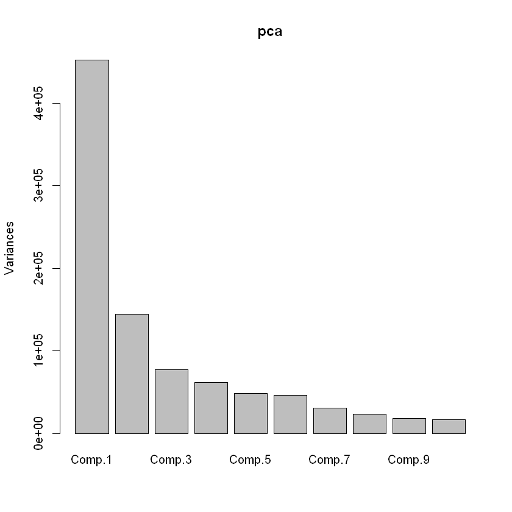

```r
#Let's apply pca on the features.
pca=princomp(Musk1[,3:ncol(Musk1)])
plot(pca)
```

```r
#We have 166 features. We see that approximately 41% of the variance is covered by the first component.
#The second component covers approximately 13% of the variance in the data and the third component covers 7% of the variance
#approximately.
summary(pca)
```

```
Importance of components:
                            Comp.1      Comp.2       Comp.3       Comp.4
Standard deviation     672.5231583 380.0653986 278.65239963 249.40875501
Proportion of Variance   0.4064954   0.1298248   0.06978574   0.05590679
Cumulative Proportion    0.4064954   0.5363202   0.60610597   0.66201276
                             Comp.5       Comp.6       Comp.7       Comp.8
Standard deviation     221.30284328 215.92511338 174.96776637 153.49043714
Proportion of Variance   0.04401646   0.04190322   0.02751422   0.02117404
Cumulative Proportion    0.70602922   0.74793244   0.77544667   0.79662071
                             Comp.9      Comp.10      Comp.11      Comp.12
Standard deviation     134.66651490 131.18007331 118.94831459 113.38519757
Proportion of Variance   0.01629898   0.01546596   0.01271621   0.01155457
Cumulative Proportion    0.81291969   0.82838565   0.84110186   0.85265643
                            Comp.13      Comp.14      Comp.15      Comp.16
Standard deviation     110.75582349 99.262822115 95.492014605 92.423175093
Proportion of Variance   0.01102489  0.008855526  0.008195496  0.007677201
Cumulative Proportion    0.86368132  0.872536845  0.880732341  0.888409542
                            Comp.17      Comp.18      Comp.19      Comp.20
Standard deviation     87.074294463 84.233002578 82.401232060 79.348358530
Proportion of Variance  0.006814297  0.006376843  0.006102511  0.005658705
Cumulative Proportion   0.895223839  0.901600681  0.907703192  0.913361897
                            Comp.21      Comp.22      Comp.23      Comp.24
Standard deviation     76.721447000 73.732685066 72.215101188 69.259075058
Proportion of Variance  0.005290232  0.004886087  0.004687024  0.004311164
Cumulative Proportion   0.918652129  0.923538216  0.928225240  0.932536404
                            Comp.25      Comp.26      Comp.27      Comp.28
Standard deviation     65.297964297 63.963958972 61.550243958 60.381761449
Proportion of Variance  0.003832132  0.003677154  0.003404871  0.003276821
Cumulative Proportion   0.936368535  0.940045689  0.943450560  0.946727381
                            Comp.29      Comp.30      Comp.31      Comp.32
Standard deviation     58.469047979 55.909825829 54.257742649 51.825660452
Proportion of Variance  0.003072509  0.002809425  0.002645846  0.002413964
Cumulative Proportion   0.949799890  0.952609315  0.955255161  0.957669125
                            Comp.33      Comp.34     Comp.35      Comp.36
Standard deviation     49.750926495 49.217654826 48.30891757 45.908283127
Proportion of Variance  0.002224557  0.002177123  0.00209747  0.001894189
Cumulative Proportion   0.959893682  0.962070805  0.96416828  0.966062464
                            Comp.37      Comp.38      Comp.39      Comp.40
Standard deviation     44.709233132 42.839275631 41.746634215 40.183250413
Proportion of Variance  0.001796535  0.001649398  0.001566333  0.001451213
```

[output cut: 114 more lines]

```
Standard deviation     2.214244e+00 2.154958e+00 2.128113e+00 1.983249e+00
Proportion of Variance 4.406481e-06 4.173677e-06 4.070337e-06 3.535052e-06
Cumulative Proportion  9.999676e-01 9.999718e-01 9.999758e-01 9.999794e-01
                           Comp.157     Comp.158     Comp.159     Comp.160
Standard deviation     1.905778e+00 1.771643e+00 1.766903e+00 1.592894e+00
Proportion of Variance 3.264269e-06 2.820938e-06 2.805863e-06 2.280419e-06
Cumulative Proportion  9.999826e-01 9.999854e-01 9.999883e-01 9.999905e-01
                           Comp.161     Comp.162     Comp.163     Comp.164
Standard deviation     1.513013e+00 1.431563e+00 1.387681e+00 1.331634e+00
Proportion of Variance 2.057436e-06 1.841884e-06 1.730695e-06 1.593716e-06
Cumulative Proportion  9.999926e-01 9.999944e-01 9.999962e-01 9.999978e-01
                           Comp.165     Comp.166
Standard deviation     1.183955e+00 1.045489e+00
Proportion of Variance 1.259829e-06 9.823805e-07
Cumulative Proportion  9.999990e-01 1.000000e+00
```

```r
#Let's also look at the eigen values. We see that the first one is the biggest one with a more remarkable difference.
#The second one is also big. The others seem smaller.
cov = cov(Musk1[,3:ncol(Musk1)])
eigen_values = eigen(cov)$values
eigen_values
```

1. 453239.582476216

2. 144753.811844365

3. 77810.6275261965

4. 62335.6843933802

5. 49078.0535987198

6. 46721.8096499581

7. 30678.1692038122

8. 23608.9128505633

9. 18173.2493306129

10. 17244.439448813

11. 14178.4882850179

12. 12883.2687178169

13. 12292.6773902842

14. 9873.85123919211

15. 9137.92216874886

16. 8560.02654327879

17. 7597.89471985832

18. 7110.13598375935

19. 6804.25770400852

20. 6309.41707932055

21. 5898.57238863618

22. 5447.95412876346

23. 5225.99983076853

24. 4806.91804521836

25. 4272.8006131572

26. 4100.00149594486

27. 3796.40817872956

28. 3653.6328148912

29. 3425.82668648972

30. 3132.48948449891

31. 2950.100327151

32. 2691.55360568316

33. 2480.36553907052

34. 2427.47728878848

35. 2338.66467796924

36. 2112.00745015336

37. 2003.12377048872

38. 1839.06712297994

39. 1746.4504818741

40. 1618.0929687274

41. 1560.13092510995

42. 1431.5043345494

43. 1375.96937459346

44. 1301.90754046756

45. 1181.50488783428

46. 1140.34835047685

47. 1067.68977316145

48. 993.699787360233

49. 980.153414618667

50. 917.743153442285

51. 868.916854168954

52. 813.988537054673

53. 792.112822267464

54. 766.276003696346

55. 746.974490031716

56. 725.809777771578

57. 662.549936117904

58. 636.015742273759

59. 567.718113576247

60. 542.824489670951

61. 536.302218064409

62. 508.950465602591

63. 493.233416629654

64. 477.684000227607

65. 454.441068547489

66. 422.426144946076

67. 411.693859831375

68. 386.077927413603

69. 370.524301674926

70. 355.540079444583

71. 339.314615940588

72. 311.049326768123

73. 307.866389004296

74. 287.436586998708

75. 280.56240304087

76. 272.001439360194

77. 251.311869033436

78. 241.65659833472

79. 233.180628037657

80. 218.748061983151

81. 214.891878682775

82. 197.796656075437

83. 187.047413209236

84. 180.058726472131

85. 173.310061584366

86. 166.473784660868

87. 152.308984469036

88. 141.584619907851

89. 138.41156473306

90. 132.746995191162

91. 127.035162968122

92. 118.820787503756

93. 115.508870338599

94. 114.33365933419

95. 106.864659734544

96. 102.929543679941

97. 102.417540612951

98. 94.5652591620287

99. 89.465527047403

100. 88.2384274421001

101. 83.4433372158852

102. 80.6829436773906

103. 79.305875125372

104. 74.7283296589996

105. 68.3633849509037

106. 64.1399244320929

107. 62.6943772180523

108. 60.8292285008246

109. 57.7443999960152

110. 55.6695385467798

111. 51.7525755863484

112. 49.8113210762519

113. 48.7730824324512

114. 46.56475786733

115. 43.3730364763636

116. 42.7150977897956

117. 39.480131628707

118. 37.4944985870058

119. 34.67917323027

120. 34.2761291037701

121. 31.6189677748407

122. 30.6935116923617

123. 29.4060002453803

124. 27.2923839964087

125. 26.1750944517519

126. 24.8583112304881

127. 24.0318384136884

128. 21.9320233405775

129. 21.7136174716597

130. 20.9054333645777

131. 18.9195020096065

132. 17.6639113760499

133. 17.0038568346239

134. 15.029067748114

135. 14.5513181982748

136. 13.9750168178128

137. 13.4563781462704

138. 12.4767722707667

139. 11.32483704387

140. 11.1207124900271

141. 10.981438565151

142. 10.3926813920133

143. 10.1605973728972

144. 8.65369295184149

145. 8.14759362546097

146. 7.72717698992373

147. 7.14301261617393

148. 7.11871850150329

149. 6.39488153684794

150. 5.95311866586829

151. 5.29569698827821

152. 5.04138806355756

153. 4.91319650806364

154. 4.65362099976447

155. 4.53839813288996

156. 3.94155908522444

157. 3.6396374683947

158. 3.14532636218375

159. 3.12851804678476

160. 2.54265150912059

161. 2.2940272342498

162. 2.05368839569482

163. 1.92971346018845

164. 1.77698252947764

165. 1.40470115506221

166. 1.09534756143056

```r
library("plot3D")
```

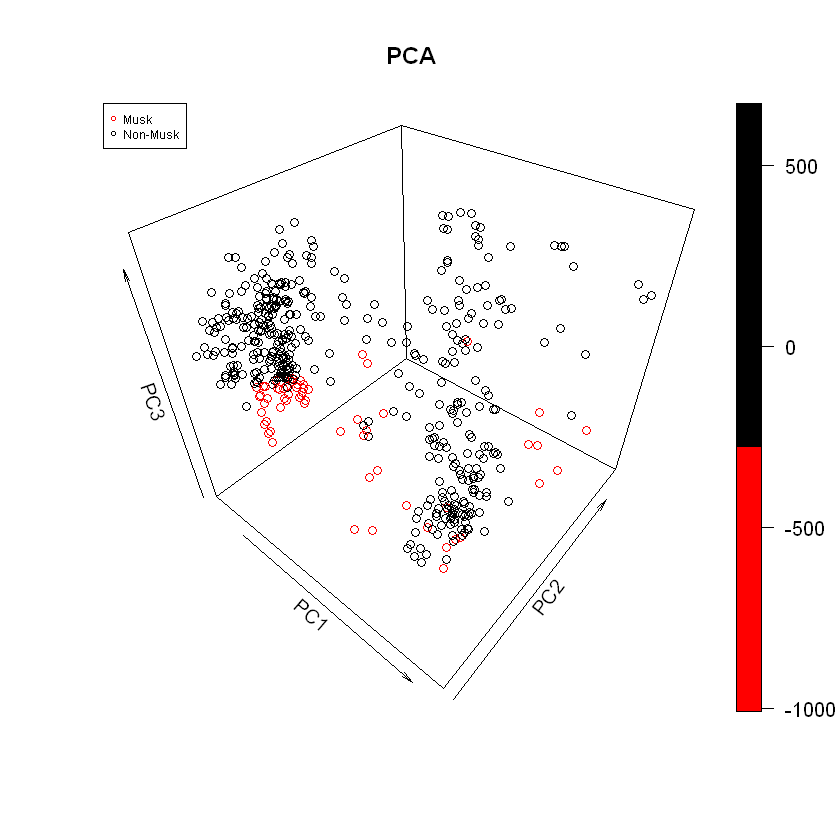

```r
#We plot first three components. Here, the instances are color coded according to their bag labels.
scatter3D(pca$scores[,1],pca$scores[,2],pca$scores[,3],main='PCA',xlab='PC1', ylab='PC2',zlab='PC3',
          col=Musk1[,1]+1)
legend("topleft", legend = c("Musk", "Non-Musk"), col = 2:1, cex=0.6, pch=c(1,1))
```

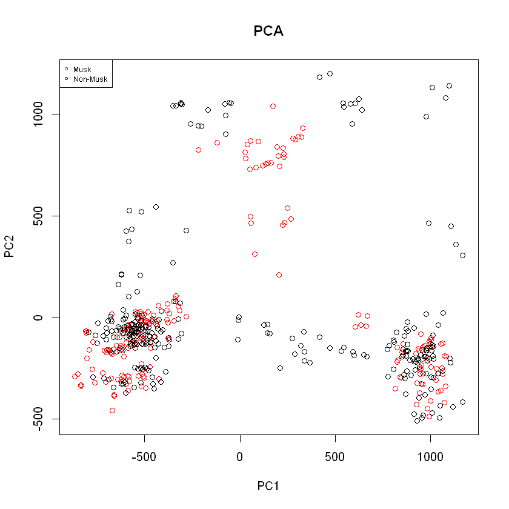

```r
#We plot first two components. Here, the instances are color coded according to their bag labels.
plot(pca$scores[,1],pca$scores[,2],main='PCA',xlab='PC1', ylab='PC2',col=Musk1[,1]+1)
legend("topleft",legend = c("Musk", "Non-Musk"), col = 2:1, cex=0.6,pch=c(1,1))
```

According to PCA we can not arrive in any clear conclusion or rule to determine the label of an instance or a bag. Assumption of the instance labels’ being as the same as bag labels also seems unsuccessful according to PCA.

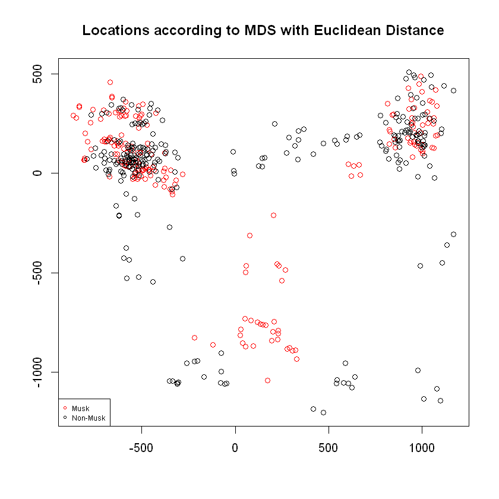

```r
#We plot according to MDS with Euclidean Distance. Here, the instances are color coded according to their bag labels.
distance_euclidean=dist(Musk1[,3:ncol(Musk1)], method="euclidean")
mds_euclidean=cmdscale(distance_euclidean)
plot(mds_euclidean[,1],mds_euclidean[,2],main='Locations according to MDS with Euclidean Distance',xlab='', ylab='',
     col=Musk1[,1]+1)
legend("bottomleft", legend = c("Musk", "Non-Musk"), col = 2:1, cex=0.6,pch=c(1,1))
```

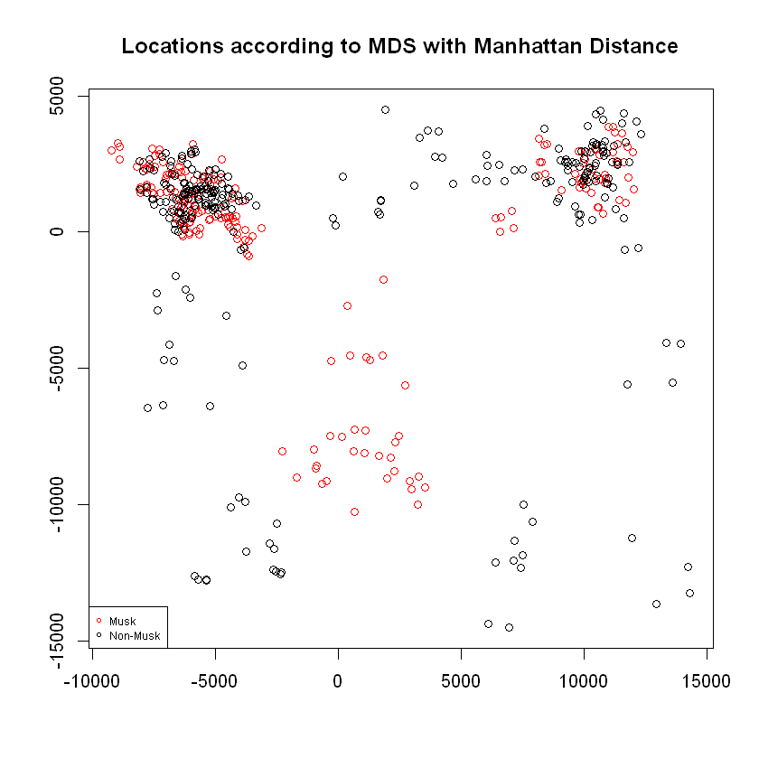

```r
#We plot according to MDS with Manhattan Distance. Here, the instances are color coded according to their bag labels.
distance_manhattan=dist(Musk1[,3:ncol(Musk1)], method="manhattan")
mds_manhattan=cmdscale(distance_manhattan)
plot(mds_manhattan[,1],mds_manhattan[,2],main='Locations according to MDS with Manhattan Distance',xlab='', ylab='',
     col=Musk1[,1]+1)
legend("bottomleft", legend = c("Musk", "Non-Musk"), col = 2:1, cex=0.6,pch=c(1,1))
```

According to MDS we can not arrive in any clear conclusion or rule to determine the label of an instance or a bag. Assumption of the instance labels’ being as the same as bag labels also seems unsuccessful according to MDS.

```r
#Let's again look at the first rows of Musk1.
head(Musk1)
```

| V1 | V2 | V3 | V4 | V5 | V6 | V7 | V8 | V9 | V10 | ... | V159 | V160 | V161 | V162 | V163 | V164 | V165 | V166 | V167 | V168 |
| --- | --- | --- | --- | --- | --- | --- | --- | --- | --- | --- | --- | --- | --- | --- | --- | --- | --- | --- | --- | --- |
| 1 | 1 | 42 | -198 | -109 | -75 | -117 | 11 | 23 | -88 | ... | -238 | -74 | -129 | -120 | -38 | 30 | 48 | -37 | 6 | 30 |
| 1 | 1 | 42 | -191 | -142 | -65 | -117 | 55 | 49 | -170 | ... | -238 | -302 | 60 | -120 | -39 | 31 | 48 | -37 | 5 | 30 |
| 1 | 1 | 42 | -191 | -142 | -75 | -117 | 11 | 49 | -161 | ... | -238 | -73 | -127 | -120 | -38 | 30 | 48 | -37 | 5 | 31 |
| 1 | 1 | 42 | -198 | -110 | -65 | -117 | 55 | 23 | -95 | ... | -238 | -302 | 60 | -120 | -39 | 30 | 48 | -37 | 6 | 30 |
| 1 | 2 | 42 | -198 | -102 | -75 | -117 | 10 | 24 | -87 | ... | -238 | -73 | -127 | 51 | 128 | 144 | 43 | -30 | 14 | 26 |
| 1 | 2 | 42 | -191 | -142 | -65 | -117 | 55 | 49 | -170 | ... | -238 | -300 | 61 | 51 | 127 | 143 | 42 | -31 | 14 | 26 |

```r
#Let's group by according to bag id and get mean of other values and look at the first rows of our data.
#The mean for bag class values for a bag id will be equal to the bag class value because all bag class values are the same for
#a bag id value. So, getting mean for bag class value will not cause a problem.
Musk1_mean=Musk1 %>% group_by(V2) %>% summarise_all("mean")
head(Musk1_mean)
```

| V2 | V1 | V3 | V4 | V5 | V6 | V7 | V8 | V9 | V10 | ... | V159 | V160 | V161 | V162 | V163 | V164 | V165 | V166 | V167 | V168 |
| --- | --- | --- | --- | --- | --- | --- | --- | --- | --- | --- | --- | --- | --- | --- | --- | --- | --- | --- | --- | --- |
| 1 | 1 | 42.00000 | -194.5000 | -125.75000 | -70.00000 | -117.0 | 33.00000 | 36.00000 | -128.5 | ... | -238.0000 | -187.75 | -34.0 | -120.00000 | -38.50000 | 30.25000 | 48.00000 | -37.00000 | 5.500000 | 30.25000 |
| 2 | 1 | 42.00000 | -194.5000 | -122.00000 | -70.00000 | -117.0 | 33.00000 | 36.25000 | -128.0 | ... | -238.0000 | -186.25 | -32.5 | 51.00000 | 126.50000 | 143.50000 | 42.75000 | -30.25000 | 14.000000 | 26.50000 |
| 3 | 1 | 42.00000 | -166.0000 | -102.50000 | -30.50000 | -116.5 | 5.00000 | 27.50000 | -142.5 | ... | -235.5000 | -57.50 | -45.5 | 13.00000 | 120.50000 | 133.50000 | 55.50000 | -32.50000 | 2.000000 | 16.50000 |
| 4 | 1 | 42.66667 | -154.6667 | -77.33333 | -42.33333 | -117.0 | 22.33333 | 21.66667 | -132.0 | ... | -237.3333 | -142.00 | -15.0 | -80.33333 | -33.66667 | 31.33333 | 50.33333 | -38.33333 | 5.333333 | 32.33333 |
| 5 | 1 | 61.50000 | -72.5000 | -102.00000 | -25.25000 | -34.0 | 19.00000 | 29.00000 | -143.5 | ... | -237.7500 | -117.25 | -60.5 | 5.00000 | 75.75000 | 136.75000 | 68.50000 | -26.75000 | -0.250000 | 36.75000 |
| 6 | 1 | 46.50000 | -148.0000 | -104.00000 | -39.50000 | -117.0 | -36.00000 | 44.00000 | -183.0 | ... | -240.0000 | -181.00 | -72.0 | 15.50000 | 75.50000 | 128.50000 | 61.50000 | -28.00000 | 8.000000 | 41.50000 |

```r
#Let's replace bag id and bag class columns. After replacing our table will start with bag class columns. Let's also look at
#the first rows of this data.
Musk1_mean=Musk1_mean[,c(2,1,3:ncol(Musk1_mean))]
head(Musk1_mean)
```

| V1 | V2 | V3 | V4 | V5 | V6 | V7 | V8 | V9 | V10 | ... | V159 | V160 | V161 | V162 | V163 | V164 | V165 | V166 | V167 | V168 |
| --- | --- | --- | --- | --- | --- | --- | --- | --- | --- | --- | --- | --- | --- | --- | --- | --- | --- | --- | --- | --- |
| 1 | 1 | 42.00000 | -194.5000 | -125.75000 | -70.00000 | -117.0 | 33.00000 | 36.00000 | -128.5 | ... | -238.0000 | -187.75 | -34.0 | -120.00000 | -38.50000 | 30.25000 | 48.00000 | -37.00000 | 5.500000 | 30.25000 |
| 1 | 2 | 42.00000 | -194.5000 | -122.00000 | -70.00000 | -117.0 | 33.00000 | 36.25000 | -128.0 | ... | -238.0000 | -186.25 | -32.5 | 51.00000 | 126.50000 | 143.50000 | 42.75000 | -30.25000 | 14.000000 | 26.50000 |
| 1 | 3 | 42.00000 | -166.0000 | -102.50000 | -30.50000 | -116.5 | 5.00000 | 27.50000 | -142.5 | ... | -235.5000 | -57.50 | -45.5 | 13.00000 | 120.50000 | 133.50000 | 55.50000 | -32.50000 | 2.000000 | 16.50000 |
| 1 | 4 | 42.66667 | -154.6667 | -77.33333 | -42.33333 | -117.0 | 22.33333 | 21.66667 | -132.0 | ... | -237.3333 | -142.00 | -15.0 | -80.33333 | -33.66667 | 31.33333 | 50.33333 | -38.33333 | 5.333333 | 32.33333 |
| 1 | 5 | 61.50000 | -72.5000 | -102.00000 | -25.25000 | -34.0 | 19.00000 | 29.00000 | -143.5 | ... | -237.7500 | -117.25 | -60.5 | 5.00000 | 75.75000 | 136.75000 | 68.50000 | -26.75000 | -0.250000 | 36.75000 |
| 1 | 6 | 46.50000 | -148.0000 | -104.00000 | -39.50000 | -117.0 | -36.00000 | 44.00000 | -183.0 | ... | -240.0000 | -181.00 | -72.0 | 15.50000 | 75.50000 | 128.50000 | 61.50000 | -28.00000 | 8.000000 | 41.50000 |

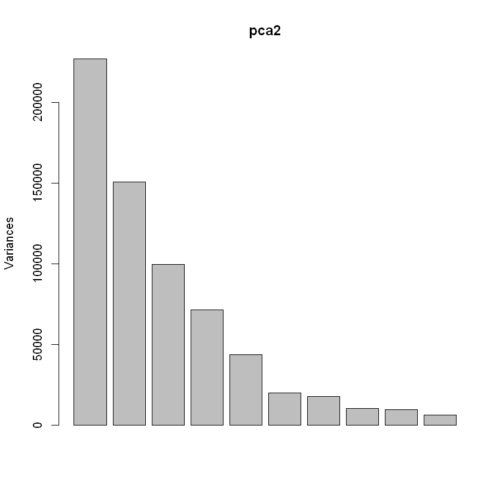

```r
#We can not make a healty pca for this situation because we do not have enough number of instances.
#Here number of instances become smaller than number of dimension after the operation above and this causes problem for pca.
#Let's use prcomp method instead of our princomp method to have an insight.
pca2=prcomp(Musk1_mean[,3:ncol(Musk1_mean)])
plot(pca2)
```